# Session 1: python syntax, variables, functions, list and loops

### Loops

We can use Python to automate tasks, such as performing a function on all items in a list. For instance, we could ask it to tell us the size of all the files in a directory. To do that, we'll have to teach the computer how to repeat things. We do this by creating something called a *loop*.

An example task that we might want to repeat is printing each character in a word on a line of its own. One way to do this would be to use a series of print statements:

```python
word = 'Python'
print(word[0])
print(word[1])
print(word[2])
print(word[3])
print(word[4])
print(word[5])
```

```
P
y
t
h
o
n
```

What are the cons of doing this do you think?

```python
word = 'Monty'
print(word[0])
print(word[1])
print(word[2])
print(word[3])
print(word[4])
print(word[5])
```

```
M
o
n
t
y
```

```
---------------------------------------------------------------------------
IndexError                                Traceback (most recent call last)
<ipython-input-38-6af80786acd1> in <module>()
      5 print(word[3])
      6 print(word[4])
----> 7 print(word[5])

IndexError: string index out of range
```

There's a better way!

```python
word = 'Python'
for char in word:
    print(char)
```

```
P
y
t
h
o
n
```

This is call a 'for loop'. Try it with other words.

The general form of a loop is:

```python
for variable in collection:
    do things with variable
```

We can call the loop variable whatever we want, but there must be a colon at the end of the line starting the loop, and we must indent anything we want to run inside the loop. This is used to signify when the loop ends, instead of using a symbol to end the loop.

This is a loop that repeatedly updates a variable:

```python
length = 0
for char in 'Python':
    length = length + 1
print('There are', length, 'letters in this word')
```

```
There are 6 letters in this word
```

Let's go through this line by line.

The variable is set to 0, so that python starts counting from 0.

The second line opens a for loop that loops over the characters in Python.

The first time around, length is zero (the value assigned to it on line 1). The statement adds 1 to the old value of length, producing 1, and updates length to refer to that new value. The next time around, char is 'y' and length is 1, so length is updated to be 2. After four more updates, length is 6.

Since there is nothing left in 'Python', the loop finishes and the print statement on line 4 tells us our final answer inbetween two strings.

Of course, we already know that we could use len() to find the length of a string, but it's just an example...

```python
len("Python")
```

```
6
```

Now for another example using a list! Fruit salad, yummy, yummy.

```python
fruits = ['banana', 'apple', 'mango']
for fruit in fruits:
    print('Current fruit :', fruit)
    print('Done!')
```

[output not shown]

**Challenge**

Define a list called Library with the 9 NLTK books in it. Write a for loop that will run our lexical_diversity() function over each book and tell you its score.

```python
Library = [text1, text2, text3, text4, text5, text6, text7, text8, text9]
for book in Library:
    score = lexical_diversity(book)
    print(book, score)
```

```
<Text: Moby Dick by Herman Melville 1851> 13
<Text: Sense and Sensibility by Jane Austen 1811> 20
<Text: The Book of Genesis> 16
<Text: Inaugural Address Corpus> 14
<Text: Chat Corpus> 7
<Text: Monty Python and the Holy Grail> 7
<Text: Wall Street Journal> 8
<Text: Personals Corpus> 4
<Text: The Man Who Was Thursday by G . K . Chesterton 1908> 10
```

### Defining variables: revisted

In Python, we give the items we're working with names, a process called assignment. For instance, in the NLTK corpus, 'Sense and Sensibility' has been assigned the name 'text2', which is much easier to work with. We also assigend the name 'sent' to the sentence that we created in the previous exercise, so that we could then instruct Python to do various things with it. Assigning a variable in python looks like this:  
variable = expression  
You can call your variables (almost) anything you like, but it's a good idea to pick names that will be meaningful and easy to type. You can't use words that already have a meaning in Python, such as import, def, or not. If you try to use a word that is reserved, you'll get a syntax error.

**Challenge**

- Create a list called 'opening' that consists of the phrase "It was a dark and stormy night; the rain fell in torrents"
- Create a variable called 'clause' that contains the contents of 'opening', up to the semi-colon
- Create a variable called 'alphabetised' that contains the contents of 'clause' sorted alphabetically
- Print 'alphabetised'

```python
opening = ['It', 'was', 'a', 'dark', 'and', 'stormy', 'night', ';', 'the', 'rain', 'fell', 'in', 'torrents']
clause = opening[0:7]
alphabetised = sorted(clause)
```

Note that assigning a variable just causes Python to remember that information without generating any output.

If you want Python to show you the result, you have to ask for it (this is a good thing when you assign a variable to a very long list!).

```python
print(clause)
```

```
['It', 'was', 'a', 'dark', 'and', 'stormy', 'night']
```

```python
print(alphabetised)
```

```
['It', 'a', 'and', 'dark', 'night', 'stormy', 'was']
```

### Frequency distributions

We can use Python's ability to perform statistical analysis of data to do further exploration of vocabulary. For instance, we might want to be able to find the most common or least common words in a text. We'll start by looking at frequency distribution.

```python
from nltk.probability import FreqDist
from collections import Counter
fdist1 = FreqDist(text1)
```

```python
fdist1.most_common(50)
```

[output not shown]

```python
fdist1['whale']
```

```
906
```

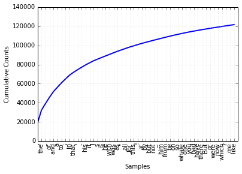

```python
fdist1.plot(50, cumulative = True)
```

**Challenge!**

Let's compare the 15 most common tokens of the texts in the NLTK book. You could do this manually, but it will save you time and typing if you define a function and then loop it over the list, 'Library', that you created earlier.

```python
def common_words(text):
    return FreqDist(text).most_common(15)
common_words(text1)
```

```
[(u',', 18713),
 (u'the', 13721),
 (u'.', 6862),
 (u'of', 6536),
 (u'and', 6024),
 (u'a', 4569),
 (u'to', 4542),
 (u';', 4072),
 (u'in', 3916),
 (u'that', 2982),
 (u"'", 2684),
 (u'-', 2552),
 (u'his', 2459),
 (u'it', 2209),
 (u'I', 2124)]
```

```python
for book in Library:
    words = common_words(book)
    print(book, words)
```

```
<Text: Moby Dick by Herman Melville 1851> [(u',', 18713), (u'the', 13721), (u'.', 6862), (u'of', 6536), (u'and', 6024), (u'a', 4569), (u'to', 4542), (u';', 4072), (u'in', 3916), (u'that', 2982), (u"'", 2684), (u'-', 2552), (u'his', 2459), (u'it', 2209), (u'I', 2124)]
<Text: Sense and Sensibility by Jane Austen 1811> [(u',', 9397), (u'to', 4063), (u'.', 3975), (u'the', 3861), (u'of', 3565), (u'and', 3350), (u'her', 2436), (u'a', 2043), (u'I', 2004), (u'in', 1904), (u'was', 1846), (u'it', 1568), (u'"', 1506), (u';', 1419), (u'she', 1333)]
<Text: The Book of Genesis> [(u',', 3681), (u'and', 2428), (u'the', 2411), (u'of', 1358), (u'.', 1315), (u'And', 1250), (u'his', 651), (u'he', 648), (u'to', 611), (u';', 605), (u'unto', 590), (u'in', 588), (u'that', 509), (u'I', 484), (u'said', 476)]
<Text: Inaugural Address Corpus> [(u'the', 9281), (u'of', 6970), (u',', 6840), (u'and', 4991), (u'.', 4676), (u'to', 4311), (u'in', 2527), (u'a', 2134), (u'our', 1905), (u'that', 1688), (u'be', 1460), (u'is', 1403), (u'we', 1141), (u'for', 1075), (u'by', 1036)]
<Text: Chat Corpus> [(u'.', 1268), (u'JOIN', 1021), (u'PART', 1016), (u'?', 737), (u'lol', 704), (u'to', 658), (u'i', 648), (u'the', 646), (u'you', 635), (u',', 596), (u'I', 576), (u'a', 568), (u'hi', 546), (u'me', 415), (u'...', 412)]
<Text: Monty Python and the Holy Grail> [(u':', 1197), (u'.', 816), (u'!', 801), (u',', 731), (u"'", 421), (u'[', 319), (u']', 312), (u'the', 299), (u'I', 255), (u'ARTHUR', 225), (u'?', 207), (u'you', 204), (u'a', 188), (u'of', 158), (u'--', 148)]
<Text: Wall Street Journal> [(u',', 4885), (u'the', 4045), (u'.', 3828), (u'of', 2319), (u'to', 2164), (u'a', 1878), (u'in', 1572), (u'and', 1511), (u'*-1', 1123), (u'0', 1099), (u'*', 965), (u"'s", 864), (u'for', 817), (u'that', 807), (u'*T*-1', 806)]
<Text: Personals Corpus> [(u',', 539), (u'.', 353), (u'/', 110), (u'for', 99), (u'to', 74), (u'and', 74), (u'lady', 68), (u'-', 66), (u'seeks', 60), (u'a', 52), (u'with', 44), (u'S', 36), (u'ship', 33), (u'&', 30), (u'relationship', 29)]
<Text: The Man Who Was Thursday by G . K . Chesterton 1908> [(u',', 3488), (u'the', 3291), (u'.', 2717), (u'a', 1713), (u'of', 1710), (u'and', 1568), (u'"', 1336), (u'to', 1045), (u'in', 888), (u'I', 885), (u'he', 858), (u'that', 841), (u'his', 765), (u'was', 716), (u'you', 580)]
```

## Exploring Vocab continued

As well as counting individual words, we can count other features of vocabulary, such as how often words of different lengths occur. We do this by putting together a number of the commands we've already learned.

We could start like this:

```
 [len(word) for word in text1]
```

... but this would print the length of every word in the whole book, so let's skip that bit!

```python
fdist2= FreqDist(len(word) for word in text1)
```

```python
fdist2.max()
```

```
3
```

```python
fdist2.freq(3)
```

```
0.19255882431878046
```

These last two commands tell us that the most common word length is 3, and that these 3 letter words account for about 20% of the book. We can see this just by visually inspecting the list produced by *fdist2.most_common()*, but if this list were too long to inspect readily, or we didn't want to print it, there are other ways to explore it.

There are a number of functions defined for NLTK's frequency distributions:

| Function | Purpose |
| --- | --- |
| fdist = FreqDist(samples) | create a frequency distribution containing the given samples |
| fdist[sample] += 1 | increment the count for this sample |
| fdist['monstrous'] | count of the number of times a given sample occurred |
| fdist.freq('monstrous') | frequency of a given sample |
| fdist.N() | total number of samples |
| fdist.most_common(n) | the n most common samples and their frequencies |
| for sample in fdist: | iterate over the items in fdist, when in the loop, we refer to each item as sample |
| fdist.max() | sample with the greatest count |
| fdist.tabulate() | tabulate the frequency distribution |
| fdist.plot() | graphical plot of the frequency distribution |
| fdist.plot(cumulative=True) | cumulative plot of the frequency distribution |
| fdist1 < fdist2 | test if samples in fdist1 occur less frequently than in fdist2 |

It is possible to select the longest words in a text, which may tell you something about its vocabulary and style

```python
vocab = set(text4)
long_words = [word for word in vocab if len(word) > 15]
sorted(long_words)
```

```
[u'RESPONSIBILITIES',
 u'antiphilosophists',
 u'constitutionally',
 u'contradistinction',
 u'discountenancing',
 u'disqualification',
 u'enthusiastically',
 u'instrumentalities',
 u'internationality',
 u'irresponsibility',
 u'misappropriation',
 u'misrepresentation',
 u'misunderstanding',
 u'responsibilities',
 u'sentimentalizing',
 u'transcontinental',
 u'uncharitableness',
 u'unconstitutional']
```

We can also use numerical operators to refine the types of searches we ask Python to run. We can use the following relational operators:

### Common relationals

| Relational | Meaning |
| --- | --- |
| < | less than |
| <= | less than or equal to |
| == | equal to (note this is two "=" signs, not one) |
| != | not equal to |
| > | greater than |
| >= | greater than or equal to |

**Challenge!**

Using one of the pre-defined sentences in the NLTK corpus, use the relational operators above to find:

- Words longer than four characters
- Words of four or more characters
- Words of exactly four characters

```python
longer = [word for word in sent2 if len(word) > 4]
more = [word for word in sent2 if len(word) >= 4]
exact = [word for word in sent2 if len(word) == 4]
print(longer, more, exact)
```

```
['family', 'Dashwood', 'settled', 'Sussex'] ['family', 'Dashwood', 'long', 'been', 'settled', 'Sussex'] ['long', 'been']
```

```python
for word in sent2:
    if len(word) > 4:
        print(word)
```

```
family
Dashwood
settled
Sussex
```

We can fine-tune our selection even further by adding other conditions. For instance, we might want to find long words that occur frequently (or rarely).

**Challenge!**

Can you find all the words in a text that are more than seven letters long and occur more than seven times?

```python
fdist5 = FreqDist(text5)
sorted(word for word in set(text5) if len(word) > 7 and fdist5[word] > 7)
```

```
[u'#14-19teens',
 u'#talkcity_adults',
 u'((((((((((',
 u'........',
 u'Question',
 u'actually',
 u'anything',
 u'computer',
 u'cute.-ass',
 u'everyone',
 u'football',
 u'innocent',
 u'listening',
 u'remember',
 u'seriously',
 u'something',
 u'together',
 u'tomorrow',
 u'watching']
```

### Common operators

| Operator | Purpose |
| --- | --- |
| s.startswith(t) | test if s starts with t |
| s.endswith(t) | test if s ends with t |
| t in s | test if t is a substring of s |
| s.islower() | test if s contains cased characters and all are lowercase |
| s.isupper() | test if s contains cased characters and all are uppercase |
| s.isalpha() | test if s is non-empty and all characters in s are alphabetic |
| s.isalnum() | test if s is non-empty and all characters in s are alphanumeric |
| s.isdigit() | test if s is non-empty and all characters in s are digits |
| s.istitle() | test if s contains cased characters and is titlecased (i.e. all words in s have initial capitals) |

```python
sorted(w for w in set(text1) if w.endswith('ableness'))
```

```
[u'comfortableness',
 u'honourableness',
 u'immutableness',
 u'indispensableness',
 u'indomitableness',
 u'intolerableness',
 u'palpableness',
 u'reasonableness',
 u'uncomfortableness']
```

```python
sorted(n for n in sent7 if n.isdigit())
```

```
['29', '61']
```

**Bonus!**

You'll remember right at the beginning we started looking at the size of the vocabulary of a text, but there were two problems with the results we got from using:

```
 len(set(text1)).
```

This count includes items of punctuation and treats capitalised and non-capitalised words as different things (*This* vs *this*). We can now fix these problems. We start by getting rid of capitalised words, then we get rid of the punctuation and numbers.

```python
len(set(text1))
```

```
19317
```

```python
len(set(word.lower() for word in text1))
```

```
17231
```

```python
len(set(word.lower() for word in text1 if word.isalpha()))
```

```
16948
```

[figure not shown]